# W10 Data Manipulation and Visualization 2

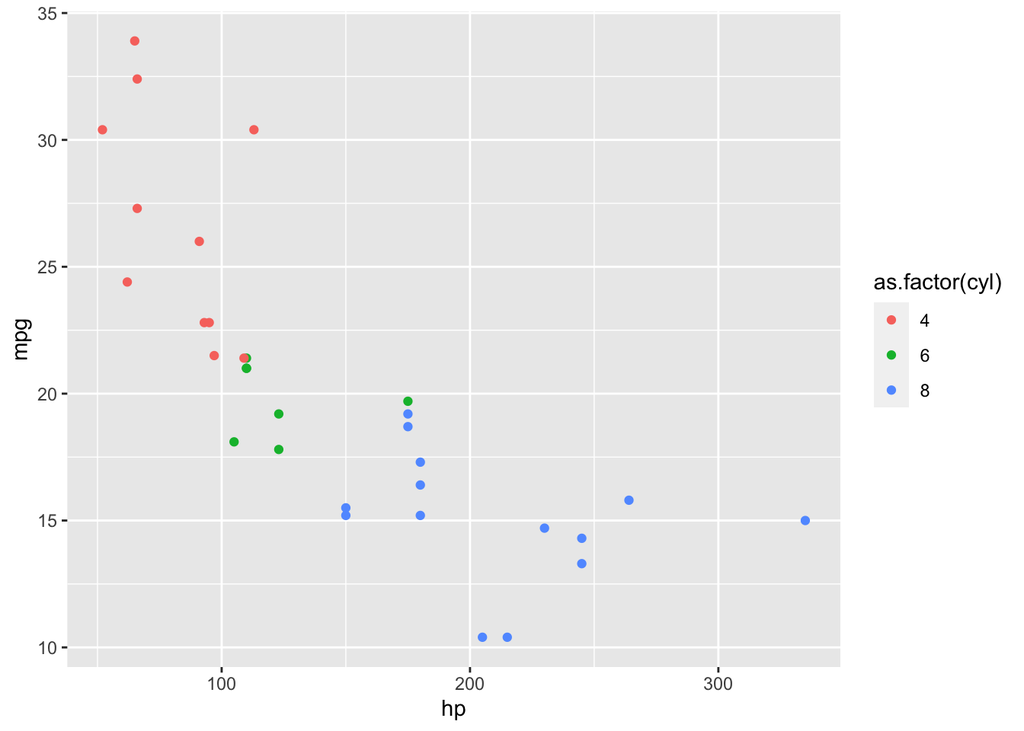

```r
mtcars%>% ggplot(aes(x= hp, y=mpg, color=as.factor(cyl))) +
  geom_point()
```

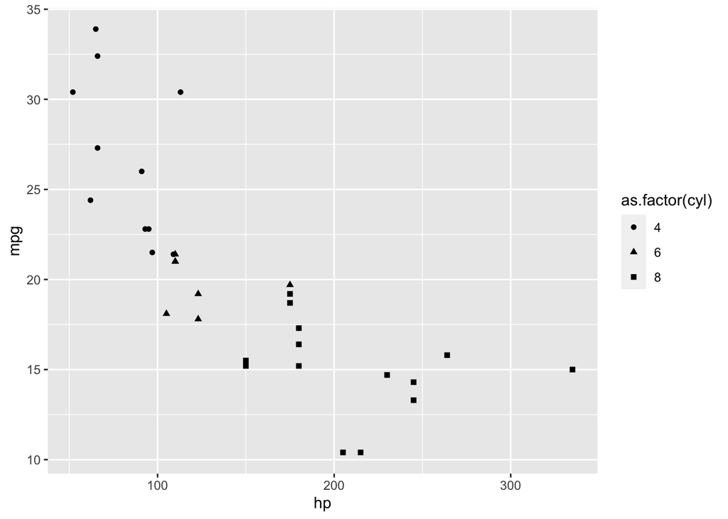

```r
mtcars%>% ggplot(aes(x= hp, y=mpg, shape=as.factor(cyl))) +
  geom_point()
```

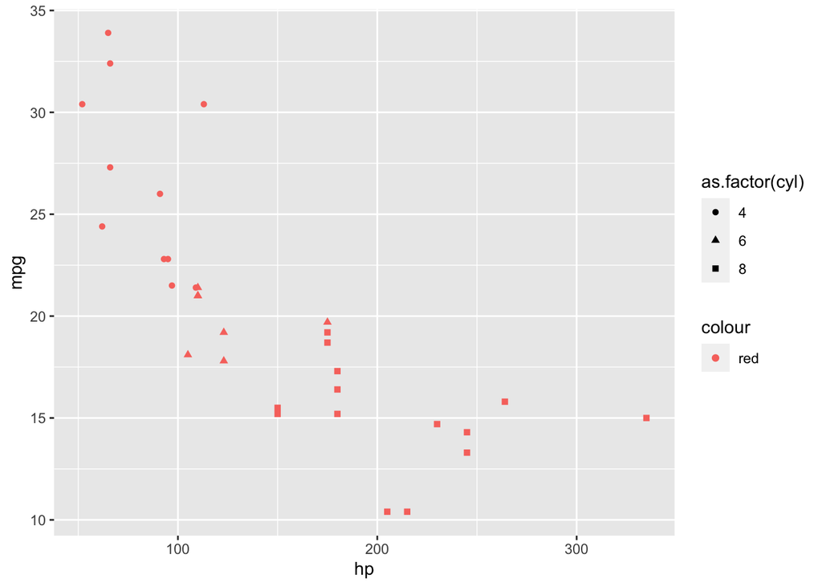

```r
mtcars%>% ggplot(aes(x= hp, y=mpg, shape=as.factor(cyl), color="red")) +
  geom_point()
```

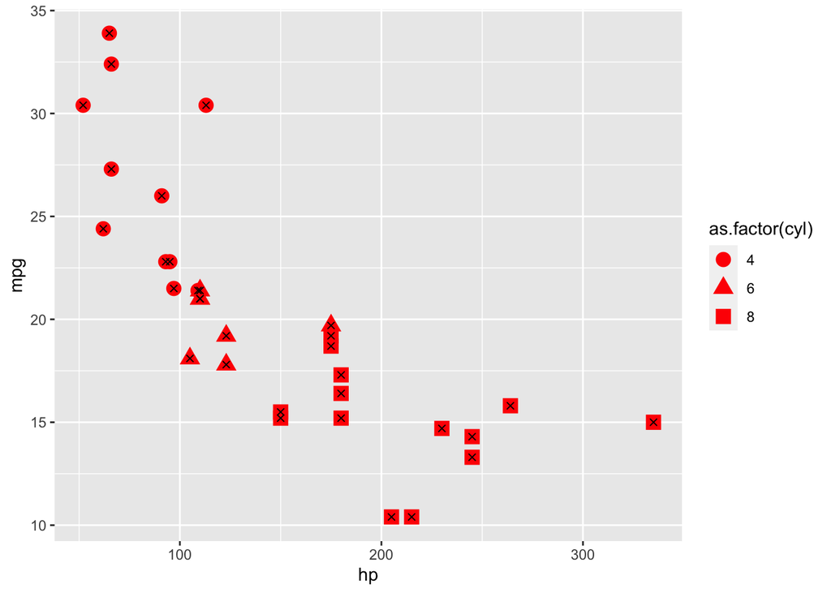

```r
mtcars%>% ggplot(aes(x= hp, y=mpg, shape=as.factor(cyl))) +
  geom_point(color="red", size=4) + geom_point(shape=4)
```

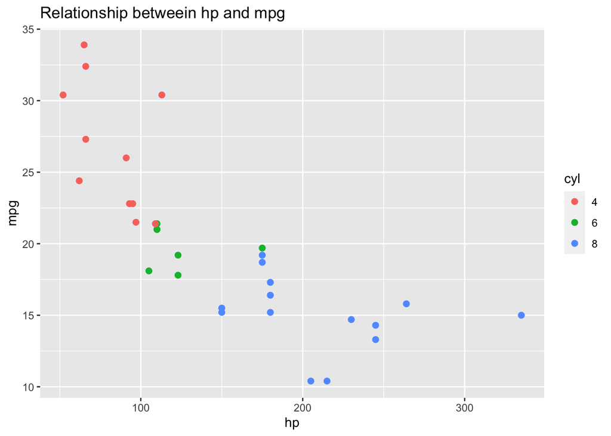

```r
mtcars%>% ggplot(aes(x= hp, y=mpg, color=as.factor(cyl))) +
  geom_point(size=2) +
  labs(title = "Relationship betweein hp and mpg", color="cyl")
```

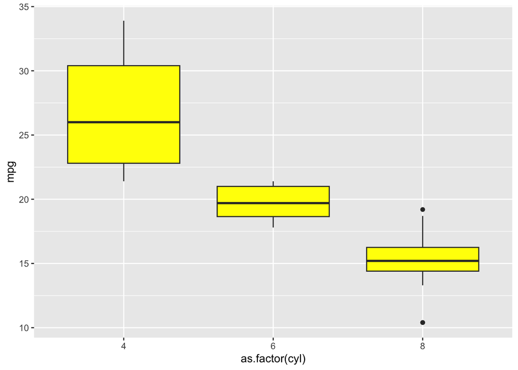

```r
mtcars%>% ggplot(aes(as.factor(cyl), mpg)) +
  geom_boxplot(fill="yellow")
```

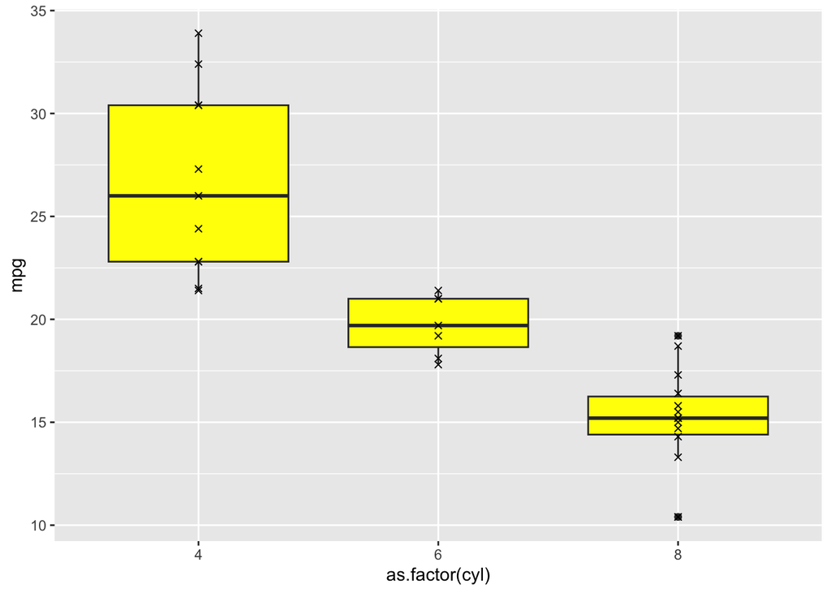

```r
mtcars%>% ggplot(aes(as.factor(cyl), mpg)) +
  geom_boxplot(fill="yellow") +
  geom_point(shape = 4)
```

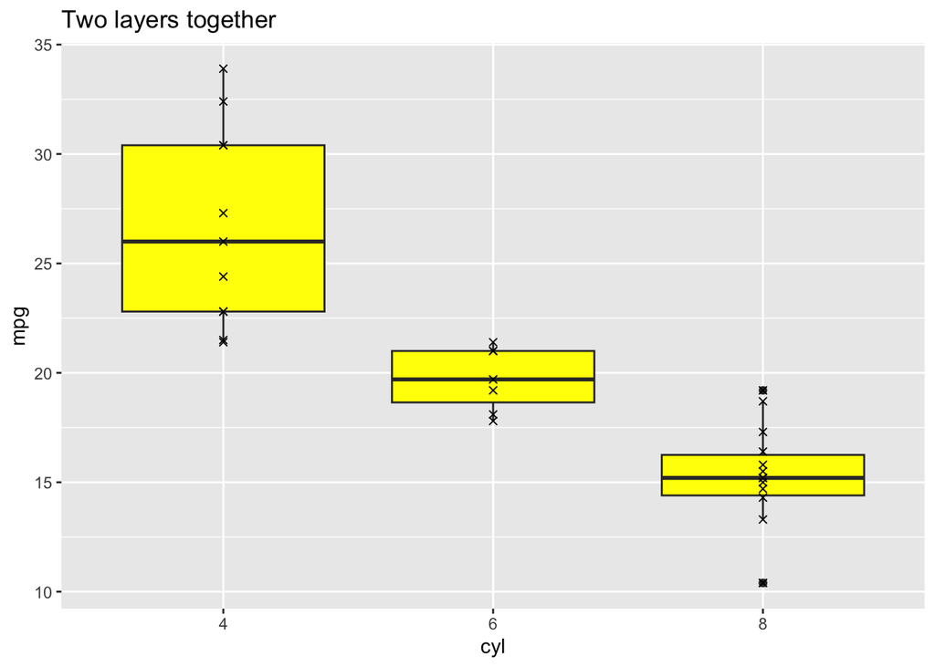

```r
mtcars%>% ggplot(aes(as.factor(cyl), mpg)) +
  geom_boxplot(fill="yellow") +
  geom_point(shape = 4) +
  labs(title="Two layers together", x="cyl")
```

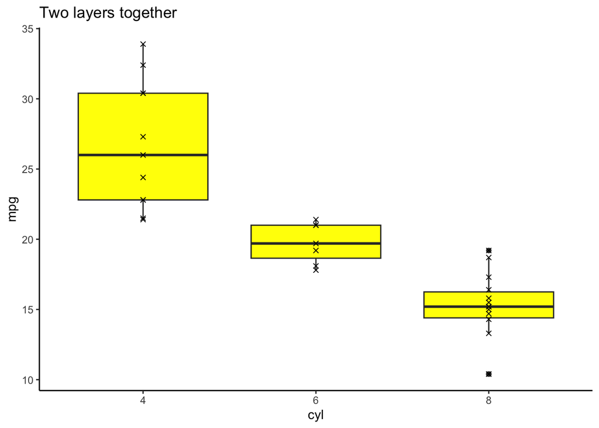

```r
mtcars%>% ggplot(aes(as.factor(cyl), mpg)) +
  geom_boxplot(fill="yellow") +
  geom_point(shape = 4) +
  labs(title="Two layers together", x="cyl") +
  theme_classic()
```

Now, getting back to our data, let’s create a stacked bar chart.

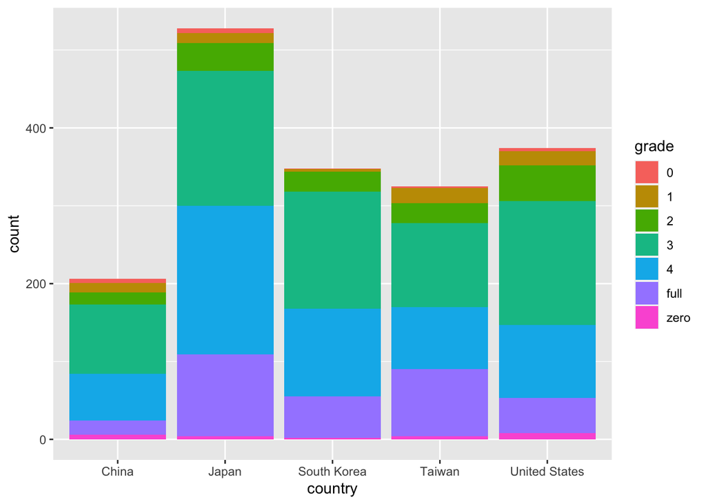

```r
ramen200_grade %>% ggplot(aes(country)) + geom_bar(aes(fill=grade))
```

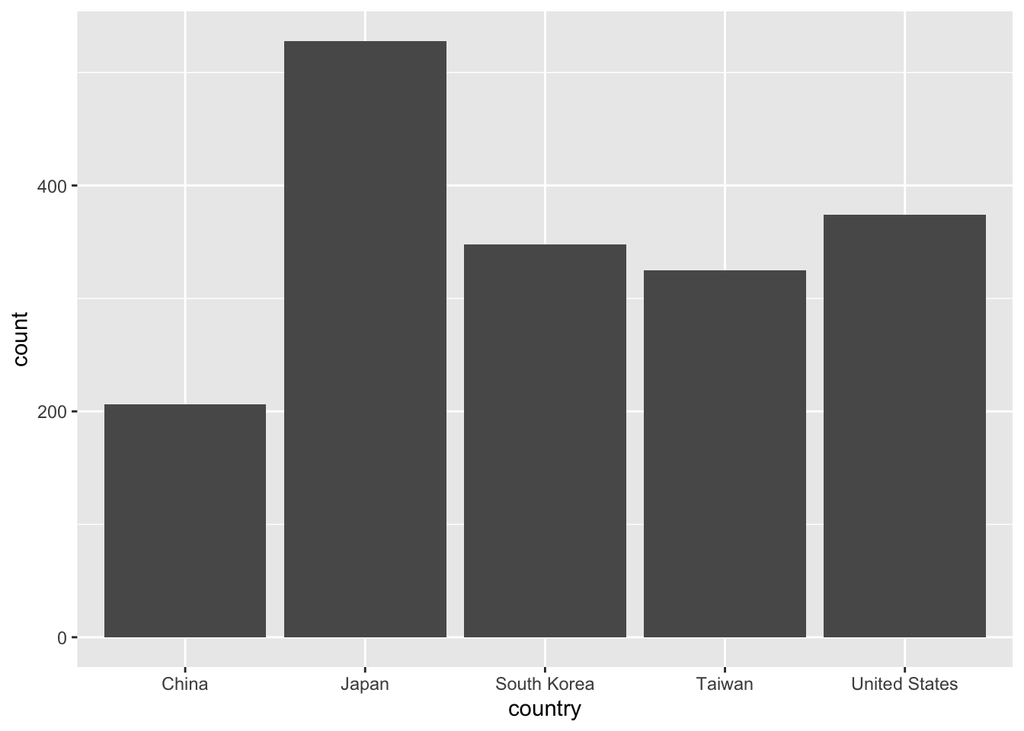

```r
ramen200_grade$grade <- as.factor(ramen200_grade$grade) %>% relevel("zero")
ramen200_grade %>% ggplot(aes(country)) + geom_bar(stat="count")
```

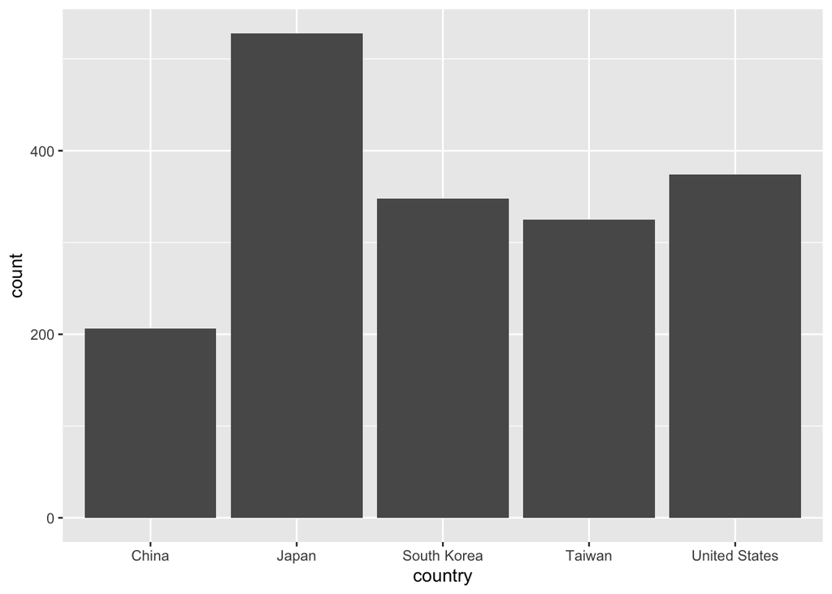

```r
ramen200_grade %>% ggplot(aes(country)) + geom_bar()
```

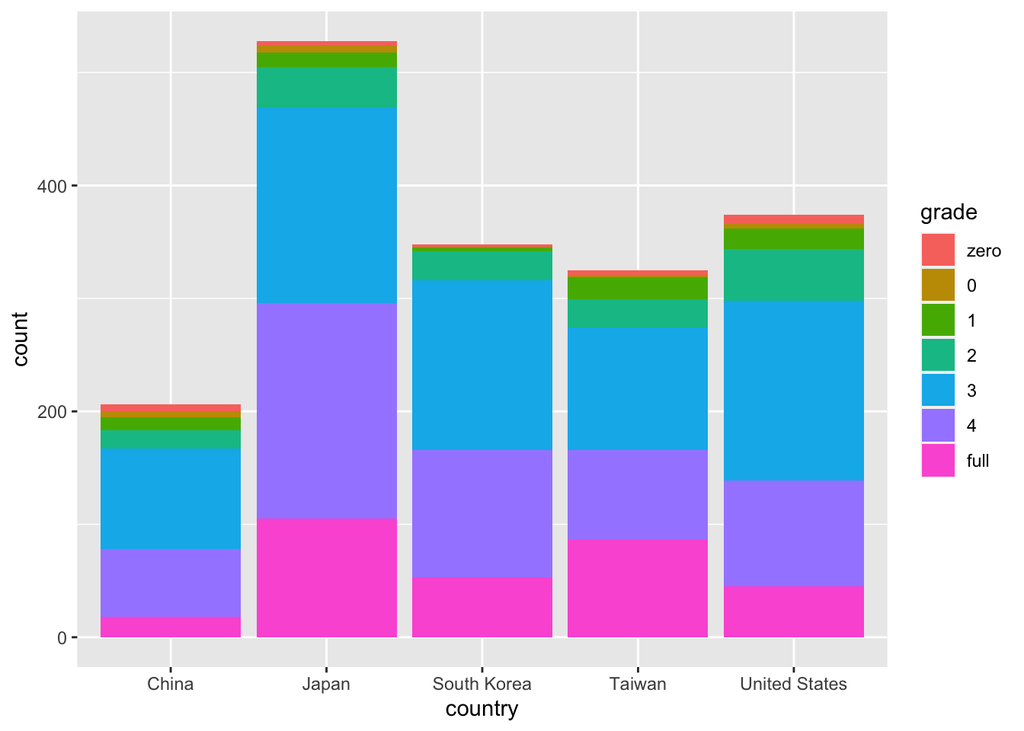

```r
ramen200_grade %>% ggplot(aes(country, fill=grade)) + geom_bar()
```

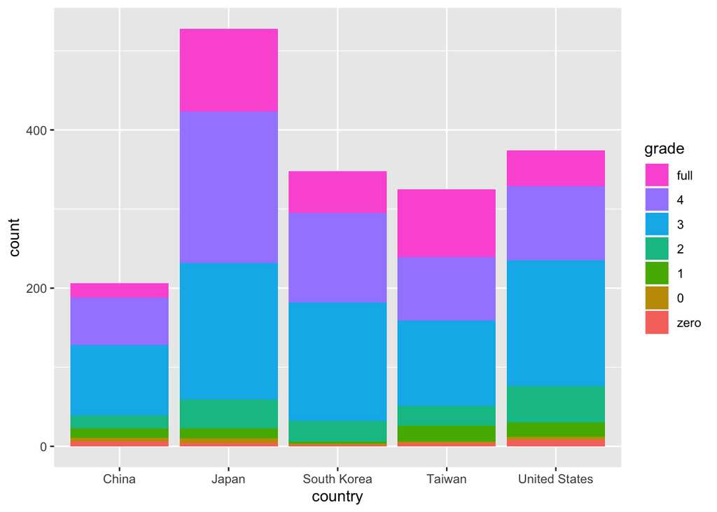

```r
ramen200_grade %>% ggplot(aes(country, fill=grade)) +
  geom_bar(position = position_stack(reverse = TRUE)) +
  guides(fill = guide_legend(reverse = TRUE))
```

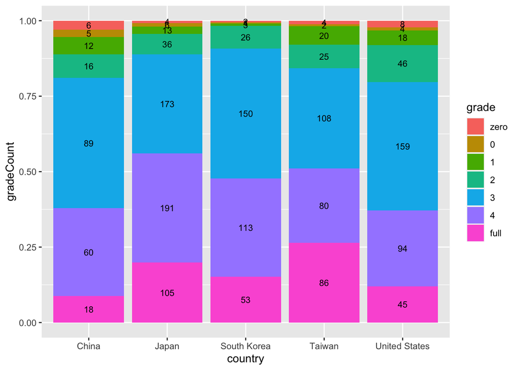

```r
ramen200_grade_summ<- ramen200_grade%>%  group_by(country, grade) %>% summarise(gradeCount=n())
ramen200_grade_summ %>% ggplot(aes(country, gradeCount, fill=grade, label=gradeCount)) +
  geom_bar(position = "fill", stat="identity") +
  geom_text(position = position_fill(vjust = .5), size=3)
```

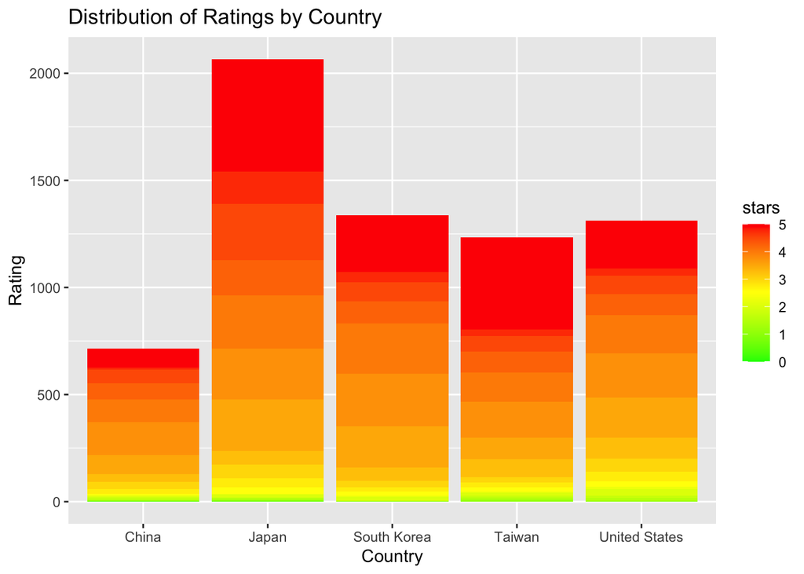

```r
# wrong graph last week! How could you know? What's wrong?
ggplot(ramen200[order(ramen200$stars),], aes(x = country, y = stars, fill = stars)) +
  geom_bar(stat = "identity") +
  scale_fill_gradient2(low = "green", high = "red", mid = "yellow", midpoint =2.5) +
    labs(
    title = "Distribution of Ratings by Country",
    x = "Country",
    y = "Rating")
```

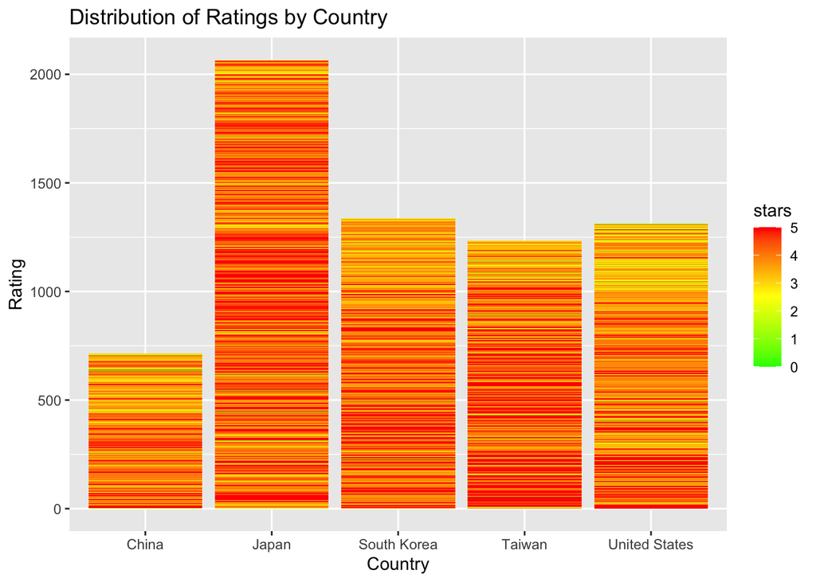

```r
#It's more obvious here. Wrong graph!
ggplot(ramen200, aes(x = country, y = stars, fill = stars)) +
  geom_bar(stat = "identity") +
  scale_fill_gradient2(low = "green", high = "red", mid = "yellow", midpoint =2.5) +
    labs(
    title = "Distribution of Ratings by Country",
    x = "Country",
    y = "Rating")
```

##### Try changing variables and options to see how `ggplot` works.

#### ❚ Map

##### World map

`map_data()` calls various map data. We are trying world map today, which means our canvas is world map.

```r
mymap <- map_data("world")
head(mymap)
```

|  | long | lat | group | order | region | subregion |
| --- | --- | --- | --- | --- | --- | --- |
| 1 | -69.89912 | 12.45200 | 1 | 1 | Aruba | NA |
| 2 | -69.89571 | 12.42300 | 1 | 2 | Aruba | NA |
| 3 | -69.94219 | 12.43853 | 1 | 3 | Aruba | NA |
| 4 | -70.00415 | 12.50049 | 1 | 4 | Aruba | NA |
| 5 | -70.06612 | 12.54697 | 1 | 5 | Aruba | NA |
| 6 | -70.05088 | 12.59707 | 1 | 6 | Aruba | NA |

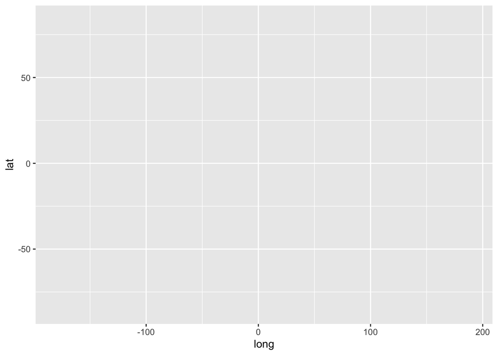

```r
ggplot(mymap, aes(x=long, y=lat))
```

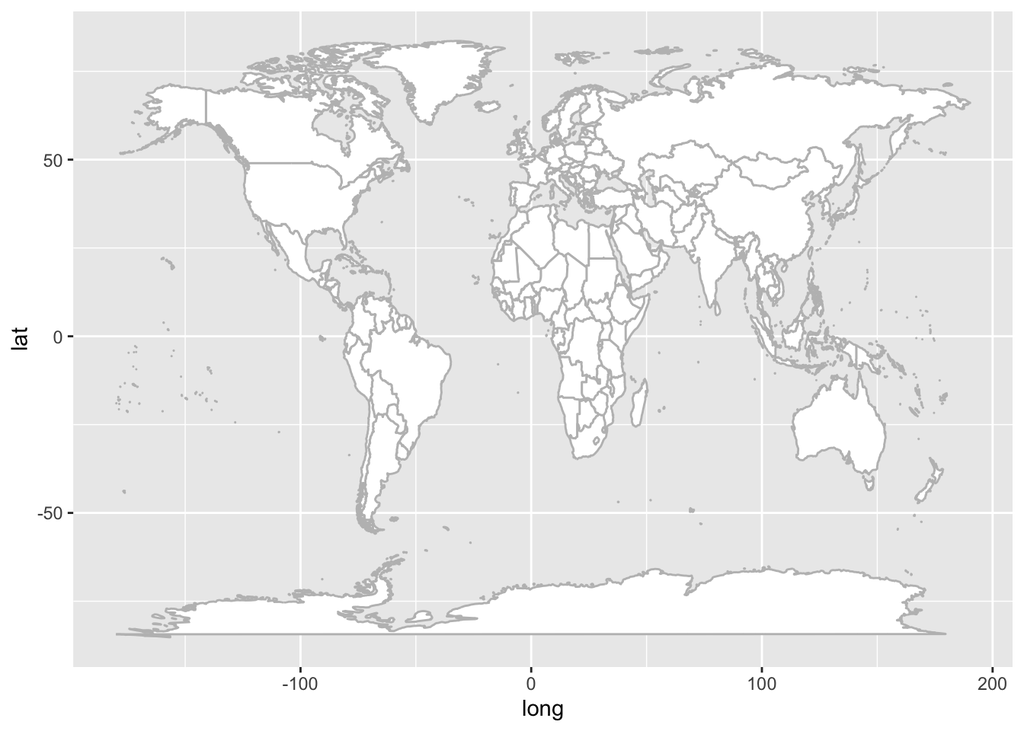

```r
ggplot(mymap, aes(x=long, y=lat)) +
  geom_map(data = mymap, map = mymap, aes(map_id=region), col = "gray", fill = "white")
```

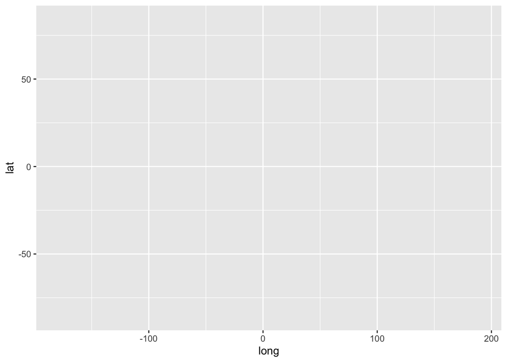

```r
mymap<- mymap %>% mutate(lastyear = if_else(region %in% c("USA", "South Korea"), "magenta", "white"))
ggplot(mymap, aes(x=long, y=lat))
```

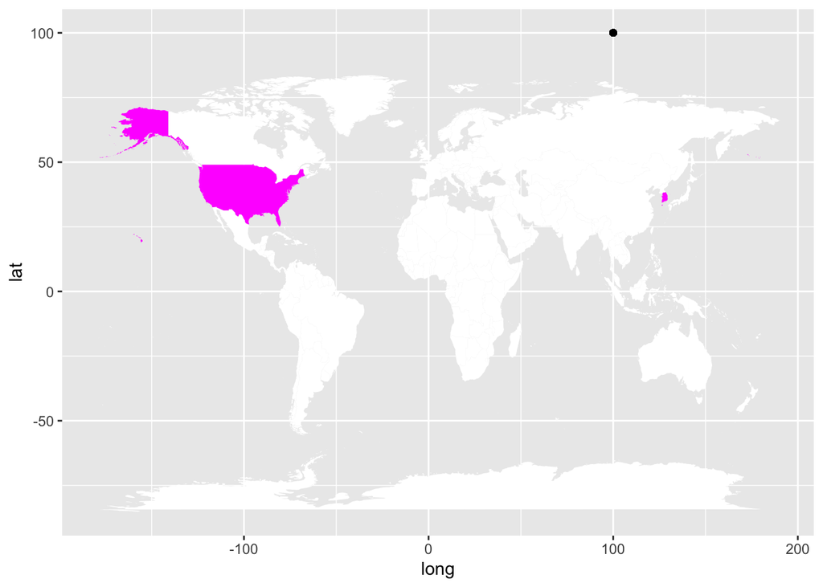

```r
mymap %>% ggplot(aes(x=long, y=lat, fill=lastyear, group = group)) +
  geom_map(map = mymap, aes(map_id = region)) + scale_fill_identity() + geom_point(aes(x=100,y=100))
```

##### Your turn.

- color the countries you’ve visited (up to 7) in “orange”
- color the countries you want to visit (up to 3) in “darkgreen”
- mark (draw a point) the deepest place on Earth with “blue” triangle
- mark the highest place on Earth with “red” triangle.

Hint: Drawing a point needs a coordination. what is x-y coordination for location?

You can find shape numbers here : https://ggplot2.tidyverse.org/articles/ggplot2-specs.html